# models

2024-11-22

### General Functions

```r
predictors <- c("year", "num_athletes", "medals_before", "is_host", "avg_age", "avg_height", "avg_weight")

# Function to compute the powerset (excluding the empty set)
powerset <- function(set) {
  n <- length(set)
  subsets <- unlist(lapply(1:n, function(k) combn(set, k, simplify = FALSE)), recursive = FALSE)

  # Filter out the empty set
  subsets <- subsets[sapply(subsets, length) > 0]

  return(subsets)
}

# Generate the powerset (including the empty set)
all_subsets <- powerset(predictors)
```

```r
# Function to fit the model on a single subset and return adjusted R-squared and MAE
fit_model_for_subset <- function(subset, train_data, test_data) {
  # Check if the subset is empty
  if (length(subset) == 0) {
    return("Empty set of predictors not allowed")
  }

  # Create formula dynamically from the subset
  formula <- as.formula(paste("total_medals ~", paste(subset, collapse = " + ")))

  # Define the recipe for preprocessing
  recipe_sub <- recipe(formula, data = train_data) %>%
    step_dummy(all_nominal()) %>%   # Create dummy variables for factors
    step_normalize(all_numeric_predictors())  # Normalise numeric predictors

  # Define the linear regression model
  model <- linear_reg() %>%
    set_engine("lm")

  # Create the workflow
  workflow_sub <- workflow() %>%
    add_recipe(recipe_sub) %>%
    add_model(model)

  # Fit the model
  fit_sub <- fit(workflow_sub, data = train_data)

  pred_sub <- predict(fit_sub, test_data) %>%
    bind_cols(test_data) %>%
    mutate(.pred = round(.pred)) %>%
    mutate(.pred = if_else(.pred < 0, 0, .pred))

  # Extract adjusted R-squared and MAE
  fit_summary <- glance(fit_sub)
  adj_r_squared <- fit_summary$adj.r.squared
  mae_value <- mae(pred_sub, truth = total_medals, estimate = .pred)$.estimate

  # Return both MAE and adjusted R-squared as a named list
  return(list(mae = mae_value, adj_r_squared = adj_r_squared))
}

evaluate_all_subsets <- function(all_subsets, train_data, test_data) {
  # Initialize an empty list to store results
  results <- list()

  # Loop through all subsets
  for (subset in all_subsets) {
    if (length(subset) == 0) {
      # Skip empty subsets
      next
    }

    # Fit the model and extract metrics
    metrics <- fit_model_for_subset(subset, train_data, test_data)

    # Store the subset, MAE, and adjusted R-squared in the results
    results[[length(results) + 1]] <- list(
      subset = paste(subset, collapse = ", "),
      mae = metrics$mae,
      adj_r_squared = metrics$adj_r_squared
    )
  }

  # Convert the list to a data frame
  results_df <- do.call(rbind, lapply(results, as.data.frame))

  # Convert MAE and adjusted R-squared to numeric
  results_df$mae <- as.numeric(results_df$mae)
  results_df$adj_r_squared <- as.numeric(results_df$adj_r_squared)

  # Arrange by ascending MAE
  results_df <- results_df[order(results_df$mae), ]

  # Return the sorted results
  return(results_df)
}
```

### Summer Olympics

- exclude 2016 Summer Olympics, use it later to test
- get top performing models, arranged by the value of MAE

```r
# Apply evaluate_all_subsets() to all subsets
results_summer <- evaluate_all_subsets(all_subsets, train_summer, test_summer)
```

- examine model with all predictors

```r
model <- linear_reg() %>%
  set_engine("lm")


recipe_s1 <- recipe(total_medals ~ num_athletes + medals_before + avg_age + avg_height + avg_weight + year + is_host,
                    data = train_summer) %>%
  step_dummy(all_nominal()) %>%
  step_normalize(all_numeric_predictors())


workflow_s1 <- workflow() %>%
  add_recipe(recipe_s1) %>%
  add_model(model)

fit_s1 <- fit(workflow_s1, data = train_summer)

tidy(fit_s1)
```

```
## # A tibble: 8 × 5
##   term          estimate std.error statistic       p.value
##   <chr>            <dbl>     <dbl>     <dbl>         <dbl>
## 1 (Intercept)    27.7        0.142   195.    0
## 2 num_athletes   49.3        0.195   253.    0
## 3 medals_before   0.328      0.185     1.77  0.0772
## 4 avg_age        -0.0224     0.145    -0.154 0.877
## 5 avg_height     -0.345      0.212    -1.63  0.103
## 6 avg_weight     -0.0919     0.210    -0.437 0.662
## 7 year           -0.901      0.147    -6.14  0.00000000121
## 8 is_host_X1      0.222      0.156     1.43  0.153
```

```r
glance(fit_s1)
```

```
## # A tibble: 1 × 12
##   r.squared adj.r.squared sigma statistic p.value    df logLik   AIC   BIC
##       <dbl>         <dbl> <dbl>     <dbl>   <dbl> <dbl>  <dbl> <dbl> <dbl>
## 1     0.992         0.992  4.38    17369.       0     7 -2750. 5517. 5561.
## # ℹ 3 more variables: deviance <dbl>, df.residual <int>, nobs <int>
```

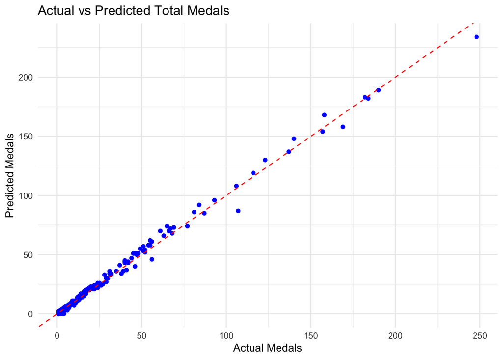

```r
pred_s1 <- predict(fit_s1, test_summer) %>%
  bind_cols(test_summer) %>%
  mutate(.pred = round(.pred)) %>%
  mutate(.pred = if_else(.pred < 0, 0, .pred))

ggplot(pred_s1, aes(x = total_medals, y = .pred)) +
  geom_point(color = "blue") +
  geom_abline(slope = 1, intercept = 0, color = "red", linetype = "dashed") +
  labs(
    title = "Actual vs Predicted Total Medals",
    x = "Actual Medals",
    y = "Predicted Medals"
  ) +
  theme_minimal()
```

```r
pred_s1
```

```
## # A tibble: 238 × 10
##    .pred  year noc   total_medals num_athletes avg_age avg_height avg_weight
##    <dbl> <dbl> <chr>        <int>        <int>   <dbl>      <dbl>      <dbl>
##  1     3  1896 DEN              6            2    25         176.       72.5
##  2     9  1896 FRA             11            7    19         176.       72.5
##  3    51  1896 GRE             48           42    22.5       176.       72.5
##  4     3  1900 AUS              6            2    22         178.       71.5
##  5     2  1900 IND              2            1    24         178.       72.6
##  6     3  1904 HUN              4            2    22         182.       77.8
##  7     8  1906 AUT              9            6    24.2       178.       85.8
##  8     6  1906 NED              6            5    27.8       179.       77.7
##  9    20  1908 DEN             17           17    24.4       177.       76.1
## 10    19  1908 NED             16           16    22.6       177.       77.6
## # ℹ 228 more rows
## # ℹ 2 more variables: is_host <fct>, medals_before <int>
```

```r
rmse(pred_s1, truth = total_medals, estimate = .pred)
```

```
## # A tibble: 1 × 3
##   .metric .estimator .estimate
##   <chr>   <chr>          <dbl>
## 1 rmse    standard        3.07
```

```r
mae(pred_s1, truth = total_medals, estimate = .pred)
```

```
## # A tibble: 1 × 3
##   .metric .estimator .estimate
##   <chr>   <chr>          <dbl>
## 1 mae     standard        1.90
```

- can do even better
- examine best model based on MAE

```r
model <- linear_reg() %>%
  set_engine("lm")


recipe_s2 <- recipe(total_medals ~  num_athletes + medals_before + avg_height + is_host,
                    data = train_summer) %>%
  step_dummy(all_nominal()) %>%
  step_normalize(all_numeric_predictors())


workflow_s2 <- workflow() %>%
  add_recipe(recipe_s2) %>%
  add_model(model)

fit_s2 <- fit(workflow_s2, data = train_summer)

tidy(fit_s2)
```

```
## # A tibble: 5 × 5
##   term          estimate std.error statistic p.value
##   <chr>            <dbl>     <dbl>     <dbl>   <dbl>
## 1 (Intercept)     27.7       0.145   192.     0
## 2 num_athletes    49.4       0.197   250.     0
## 3 medals_before    0.122     0.185     0.659  0.510
## 4 avg_height      -0.358     0.147    -2.44   0.0150
## 5 is_host_X1       0.283     0.158     1.79   0.0737
```

```r
glance(fit_s2)
```

```
## # A tibble: 1 × 12
##   r.squared adj.r.squared sigma statistic p.value    df logLik   AIC   BIC
##       <dbl>         <dbl> <dbl>     <dbl>   <dbl> <dbl>  <dbl> <dbl> <dbl>
## 1     0.992         0.992  4.46    29294.       0     4 -2768. 5549. 5578.
## # ℹ 3 more variables: deviance <dbl>, df.residual <int>, nobs <int>
```

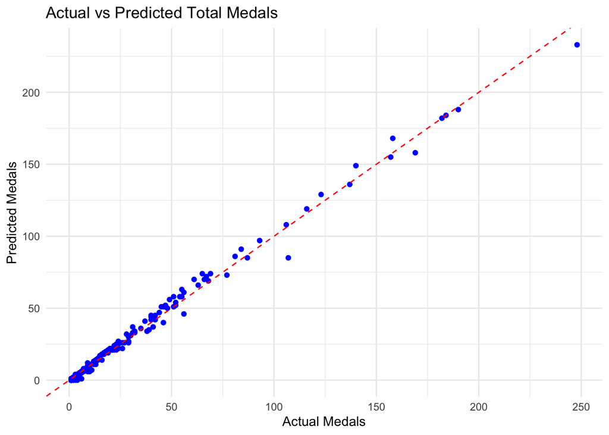

```r
pred_s2 <- predict(fit_s2, test_summer) %>%
  bind_cols(test_summer) %>%
  mutate(.pred = round(.pred)) %>%
  mutate(.pred = if_else(.pred < 0, 0, .pred))

ggplot(pred_s2, aes(x = total_medals, y = .pred)) +
  geom_point(color = "blue") +
  geom_abline(slope = 1, intercept = 0, color = "red", linetype = "dashed") +
  labs(
    title = "Actual vs Predicted Total Medals",
    x = "Actual Medals",
    y = "Predicted Medals"
  ) +
  theme_minimal()
```

```r
pred_s2
```

```
## # A tibble: 238 × 10
##    .pred  year noc   total_medals num_athletes avg_age avg_height avg_weight
##    <dbl> <dbl> <chr>        <int>        <int>   <dbl>      <dbl>      <dbl>
##  1     1  1896 DEN              6            2    25         176.       72.5
##  2     7  1896 FRA             11            7    19         176.       72.5
##  3    50  1896 GRE             48           42    22.5       176.       72.5
##  4     1  1900 AUS              6            2    22         178.       71.5
##  5     0  1900 IND              2            1    24         178.       72.6
##  6     1  1904 HUN              4            2    22         182.       77.8
##  7     6  1906 AUT              9            6    24.2       178.       85.8
##  8     5  1906 NED              6            5    27.8       179.       77.7
##  9    19  1908 DEN             17           17    24.4       177.       76.1
## 10    18  1908 NED             16           16    22.6       177.       77.6
## # ℹ 228 more rows
## # ℹ 2 more variables: is_host <fct>, medals_before <int>
```

```r
rmse(pred_s2, truth = total_medals, estimate = .pred)
```

```
## # A tibble: 1 × 3
##   .metric .estimator .estimate
##   <chr>   <chr>          <dbl>
## 1 rmse    standard        3.18
```

```r
mae(pred_s2, truth = total_medals, estimate = .pred)
```

```
## # A tibble: 1 × 3
##   .metric .estimator .estimate
##   <chr>   <chr>          <dbl>
## 1 mae     standard        1.81
```

```r
results_summer %>%
  filter(mae < 2)%>%
  count()
```

```
##    n
## 1 64
```

- note that top 2 have MAE = 1.81 to 3 sf
- top 22 - 1.8 to 2 sf
- top 64 - 2 to 1 sf
- no big differences, so best models will give pretty much the same values for predicted number of medals (differences likely to be more visible when number of medals is low)
- half of the models have average deviation from the real number of total medals won of 2 medals
- compare predicted and actual total medals using 2016 Summer Olympics

```r
summer_2016 <- medals_summer %>%
  filter(year == "2016")

pred_2016 <- predict(fit_s2, summer_2016) %>%
  bind_cols(summer_2016) %>%
  mutate(.pred = round(.pred)) %>%
  mutate(.pred = if_else(.pred < 0, 0, .pred)) %>%
  select(noc, total_medals, .pred) %>%
  arrange(desc(total_medals)) %>%
  mutate(pct_error = ((abs(total_medals - .pred))/total_medals) * 100)

pred_2016 %>% slice_head(n = 10)
```

```
## # A tibble: 10 × 4
##    noc   total_medals .pred pct_error
##    <chr>        <int> <dbl>     <dbl>
##  1 USA            264   245      7.20
##  2 GER            159   173      8.81
##  3 GBR            145   150      3.45
##  4 RUS            115   119      3.48
##  5 CHN            113   116      2.65
##  6 FRA             96   107     11.5
##  7 AUS             82    82      0
##  8 ITA             72    79      9.72
##  9 CAN             69    72      4.35
## 10 JPN             64    66      3.12
```

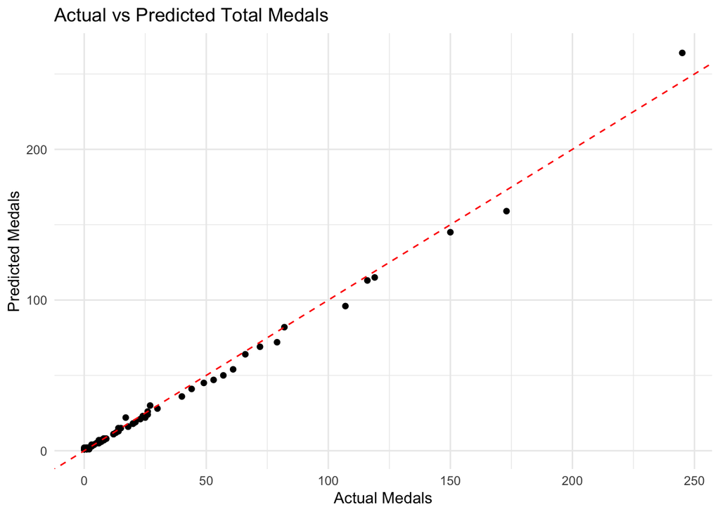

```r
pred_2016 %>%
  ggplot(mapping = aes(x = .pred, y = total_medals)) +
  geom_point() +
  geom_abline(slope = 1, intercept = 0, color = "red", linetype = "dashed") +
  labs(
    title = "Actual vs Predicted Total Medals",
    x = "Actual Medals",
    y = "Predicted Medals"
  ) +
  theme_minimal()
```

```r
pred_2016 %>%
  filter(total_medals > 25) %>%
  summarise(avg_error = mean(pct_error))
```

```
## # A tibble: 1 × 1
##   avg_error
##       <dbl>
## 1      7.29
```

```r
rmse(pred_2016, truth = total_medals, estimate = .pred)
```

```
## # A tibble: 1 × 3
##   .metric .estimator .estimate
##   <chr>   <chr>          <dbl>
## 1 rmse    standard        3.54
```

```r
mae(pred_2016, truth = total_medals, estimate = .pred)
```

```
## # A tibble: 1 × 3
##   .metric .estimator .estimate
##   <chr>   <chr>          <dbl>
## 1 mae     standard        1.87
```

```r
pred_2016 %>%
  summarise(avg = mean(total_medals))
```

```
## # A tibble: 1 × 1
##     avg
##   <dbl>
## 1  23.5
```

### Winter Olympics

- get top performing models, arranged by the value of MAE

```r
# Apply evaluate_all_subsets() to all subsets
results_winter <- evaluate_all_subsets(all_subsets, train_winter, test_winter)

head(results_winter)
```

```
##                                                                    subset
## 85                       num_athletes, medals_before, is_host, avg_height
## 116          num_athletes, medals_before, is_host, avg_height, avg_weight
## 114             num_athletes, medals_before, is_host, avg_age, avg_height
## 126 num_athletes, medals_before, is_host, avg_age, avg_height, avg_weight
## 117          num_athletes, medals_before, avg_age, avg_height, avg_weight
## 49                                      num_athletes, is_host, avg_height
##          mae adj_r_squared
## 85  1.806723     0.9919575
## 116 1.806723     0.9919494
## 114 1.815126     0.9919528
## 126 1.815126     0.9919450
## 117 1.819328     0.9919272
## 49  1.823529     0.9919623
```

- examine model with all predictors

```r
model <- linear_reg() %>%
  set_engine("lm")


recipe_w1 <- recipe(total_medals ~ num_athletes + medals_before + avg_age + avg_height + avg_weight + year + is_host,
                    data = train_winter) %>%
  step_dummy(all_nominal()) %>%
  step_normalize(all_numeric_predictors())


workflow_w1 <- workflow() %>%
  add_recipe(recipe_w1) %>%
  add_model(model)

fit_w1 <- fit(workflow_w1, data = train_winter)

tidy(fit_w1)
```

```
## # A tibble: 8 × 5
##   term          estimate std.error statistic       p.value
##   <chr>            <dbl>     <dbl>     <dbl>         <dbl>
## 1 (Intercept)    27.7        0.142   195.    0
## 2 num_athletes   49.3        0.195   253.    0
## 3 medals_before   0.328      0.185     1.77  0.0772
## 4 avg_age        -0.0224     0.145    -0.154 0.877
## 5 avg_height     -0.345      0.212    -1.63  0.103
## 6 avg_weight     -0.0919     0.210    -0.437 0.662
## 7 year           -0.901      0.147    -6.14  0.00000000121
## 8 is_host_X1      0.222      0.156     1.43  0.153
```

```r
glance(fit_w1)
```

```
## # A tibble: 1 × 12
##   r.squared adj.r.squared sigma statistic p.value    df logLik   AIC   BIC
##       <dbl>         <dbl> <dbl>     <dbl>   <dbl> <dbl>  <dbl> <dbl> <dbl>
## 1     0.992         0.992  4.38    17369.       0     7 -2750. 5517. 5561.
## # ℹ 3 more variables: deviance <dbl>, df.residual <int>, nobs <int>
```

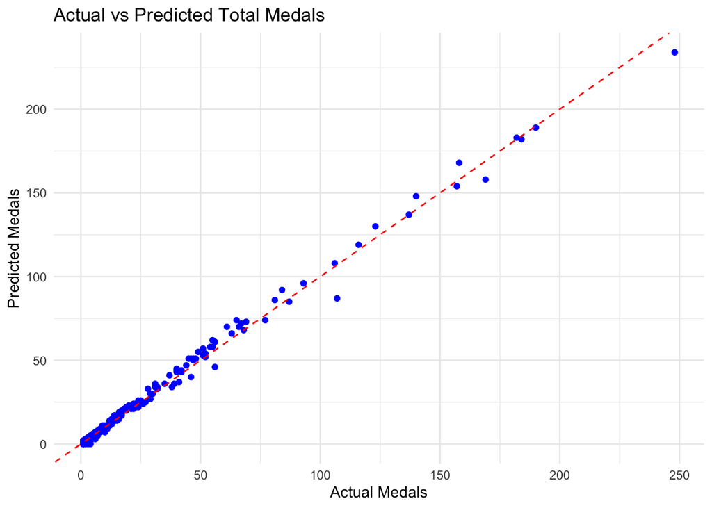

```r
pred_w1 <- predict(fit_w1, test_winter) %>%
  bind_cols(test_winter) %>%
  mutate(.pred = round(.pred)) %>%
  mutate(.pred = if_else(.pred < 0, 0, .pred))

ggplot(pred_w1, aes(x = total_medals, y = .pred)) +
  geom_point(color = "blue") +
  geom_abline(slope = 1, intercept = 0, color = "red", linetype = "dashed") +
  labs(
    title = "Actual vs Predicted Total Medals",
    x = "Actual Medals",
    y = "Predicted Medals"
  ) +
  theme_minimal()
```

```r
pred_w1
```

```
## # A tibble: 238 × 10
##    .pred  year noc   total_medals num_athletes avg_age avg_height avg_weight
##    <dbl> <dbl> <chr>        <int>        <int>   <dbl>      <dbl>      <dbl>
##  1     3  1896 DEN              6            2    25         176.       72.5
##  2     9  1896 FRA             11            7    19         176.       72.5
##  3    51  1896 GRE             48           42    22.5       176.       72.5
##  4     3  1900 AUS              6            2    22         178.       71.5
##  5     2  1900 IND              2            1    24         178.       72.6
##  6     3  1904 HUN              4            2    22         182.       77.8
##  7     8  1906 AUT              9            6    24.2       178.       85.8
##  8     6  1906 NED              6            5    27.8       179.       77.7
##  9    20  1908 DEN             17           17    24.4       177.       76.1
## 10    19  1908 NED             16           16    22.6       177.       77.6
## # ℹ 228 more rows
## # ℹ 2 more variables: is_host <fct>, medals_before <int>
```

```r
rmse(pred_w1, truth = total_medals, estimate = .pred)
```

```
## # A tibble: 1 × 3
##   .metric .estimator .estimate
##   <chr>   <chr>          <dbl>
## 1 rmse    standard        3.07
```

```r
mae(pred_w1, truth = total_medals, estimate = .pred)
```

```
## # A tibble: 1 × 3
##   .metric .estimator .estimate
##   <chr>   <chr>          <dbl>
## 1 mae     standard        1.90
```

```r
model <- linear_reg() %>%
  set_engine("lm")


recipe_w2 <- recipe(total_medals ~ num_athletes + avg_weight + year + medals_before,
                    data = train_winter) %>%
  step_dummy(all_nominal()) %>%
  step_normalize(all_numeric_predictors())


workflow_w2 <- workflow() %>%
  add_recipe(recipe_w2) %>%
  add_model(model)

fit_w2 <- fit(workflow_w2, data = train_winter)

tidy(fit_w2)
```

```
## # A tibble: 5 × 5
##   term          estimate std.error statistic  p.value
##   <chr>            <dbl>     <dbl>     <dbl>    <dbl>
## 1 (Intercept)     27.7       0.142    195.   0
## 2 num_athletes    49.4       0.181    273.   0
## 3 avg_weight      -0.352     0.143     -2.46 1.40e- 2
## 4 year            -0.907     0.145     -6.25 6.08e-10
## 5 medals_before    0.260     0.183      1.42 1.55e- 1
```

```r
glance(fit_w2)
```

```
## # A tibble: 1 × 12
##   r.squared adj.r.squared sigma statistic p.value    df logLik   AIC   BIC
##       <dbl>         <dbl> <dbl>     <dbl>   <dbl> <dbl>  <dbl> <dbl> <dbl>
## 1     0.992         0.992  4.38    30335.       0     4 -2752. 5516. 5545.
## # ℹ 3 more variables: deviance <dbl>, df.residual <int>, nobs <int>
```